# Mobility Trend Analytics During Covid-19

By Dhanush Krishnan

```r
#Libraries Import

library(tidyverse)
library(knitr)
library(emmeans)
library(car)
library(gridExtra)
```

This report fulfills the following requests to perform specific analyses that examine the effect of COVID response schemes such as Work from Home, Rule of 6 Indoors, and the Eat Out upon the number of bike rentals in the Santander Cycle Hire Scheme

- Perform a regression analysis that examine the effect on the number of bike rentals due to three elements of the COVID response: Work from Home, Rule of 6 Indoors, and the Eat Out to Help Out scheme
- Analyse if it is appropriate to control for the effect of potential differences between different years, months, and days of the week

Data is used from the London bike hire scheme (https://data.london.gov.uk/dataset/number-bicycle-hires) Each row is about one day in the period from 30th July 2010 to 30th September 2023

## Data Dictionary

| Variable | Description |
| --- | --- |
| `date` | Date |
| `Hires` | Count of the number of bike hires on the respective date |
| `schools_closed` | Covid Restriction : School closures - complete closures only 1 = implemented, 0 = not implemented |
| `pubs_closed` | Covid Restriction : Pub closures - excluding pubs that serve food 1 = implemented, 0 = not implemented |
| `shops_closed` | Covid Restriction : Shop closures - non-essential 1 = implemented, 0 = not implemented |
| `eating_places_closed` | Covid Restriction : Eating Places closures - including pubs that serve food 1 = implemented, 0 = not implemented |
| `stay_at_home` | Covid Restriction : Stay at home orders 1=implemented, 0=not implemented |
| `household_mixing_indoors_banned` | Covid Restriction : Household mixing indoors banned 1=implemented, 0=not implemented |
| `wfh` | Covid Restriction : Working from home encouraged 1=implemented, 0=not implemented |
| `rule_of_6_indoors` | Covid Restriction : Rule of 6 indoors 1=implemented, 0=not implemented |
| `curfew` | Covid Restriction : 10pm curfew on hospitality 1=implemented, 0=not implemented |
| `eat_out_to_help_out` | Covid Restriction : Eat Out to Help Out scheme 1=implemented, 0=not implemented |
| `day` | day of week |
| `month` | month |
| `year` | year |

```r
#Read csv and store it in data frame bikes_data
bikes_data <- read.csv('London_COVID_bikes.csv',stringsAsFactors = TRUE)


#Convert the required columns into factors
bikes_data$schools_closed<- factor(bikes_data$schools_closed,c(0,1))
bikes_data$pubs_closed<- factor(bikes_data$pubs_closed,c(0,1))
bikes_data$shops_closed<- factor(bikes_data$shops_closed,c(0,1))
bikes_data$eating_places_closed<- factor(bikes_data$eating_places_closed,c(0,1))
bikes_data$stay_at_home<- factor(bikes_data$stay_at_home,c(0,1))
bikes_data$household_mixing_indoors_banned<- factor(bikes_data$household_mixing_indoors_banned,c(0,1))
bikes_data$wfh<- factor(bikes_data$wfh,c(0,1))
bikes_data$rule_of_6_indoors<- factor(bikes_data$rule_of_6_indoors,c(0,1))
bikes_data$curfew<- factor(bikes_data$curfew,c(0,1))
bikes_data$eat_out_to_help_out<- factor(bikes_data$eat_out_to_help_out,c(0,1))
bikes_data$year<- factor(bikes_data$year,levels=c('2010','2011','2012','2013','2014','2015','2016','2017','2018','2019','2020','2021','2022','2023'))
bikes_data$month <- factor(bikes_data$month,levels=c('Jan','Feb','Mar','Apr','May','Jun','Jul','Aug','Sep','Oct','Nov','Dec'))
```

## Data Integrity Checks

### NULL/NA Checks

```r
#Function to check for NULL values in each column

cols <- data.frame(sapply(bikes_data ,function(x) sum(is.na(x))),row.names = NULL)


#Table to highlight number of NULL values for each Column

cols <- cbind("Column Names" = colnames(bikes_data), cols)

colnames(cols)[2] <- "Count of NULL values"

kable(cols, caption = "Table that gives the count of NULL values for each column")
```

Table that gives the count of NULL values for each column

| Column Names | Count of NULL values |
| --- | --- |
| date | 0 |
| Hires | 0 |
| schools_closed | 0 |
| pubs_closed | 0 |
| shops_closed | 0 |
| eating_places_closed | 0 |
| stay_at_home | 0 |
| household_mixing_indoors_banned | 0 |
| wfh | 0 |
| rule_of_6_indoors | 0 |
| curfew | 0 |
| eat_out_to_help_out | 0 |
| day | 0 |
| month | 0 |
| year | 0 |

We note that there no NULL values present in the dataset for any action to be taken.

### Outlier Checks

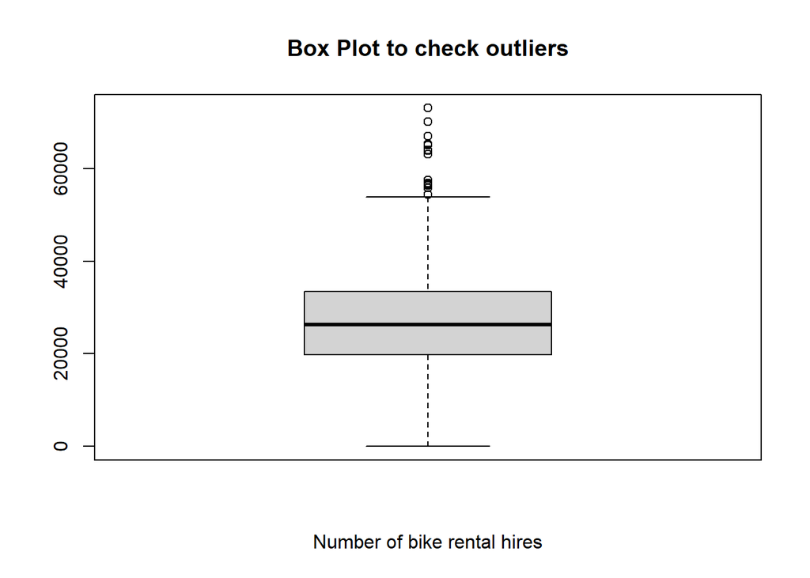

```r
#Boxplot which checks for outlier in column Hires

boxplot <- boxplot(bikes_data$Hires, main='Box Plot to check outliers', xlab='Number of bike rental hires')
```

```r
#Table to indicate the outliers
outliers <- as.data.frame(boxplot$out, nm = 'Outlier Values')

#Arrange in descending order

(outliers[order(outliers$`Outlier Values`,decreasing = TRUE),])
```

```
##  [1] 73094 70170 67034 66972 65326 65045 64041 63963 63116 57516 56922 56654
## [13] 56568 56320 55805 54360
```

Outliers from the boxplot analysis need not be removed as the maximum value of 73094 bike hires does not seem like a exceptional high value that needs some action to be taken.

## Regression Analysis-To examine the effect on the number of bike rentals due to COVID response schemes: Work From Home, Rule of 6 Indoors, and the Eat Out to Help Out

### Simple Regression Analysis to show the effect on bike hires due to the COVID restriction : Work from Home

```r
#Simple Regression model to check the effect of work from home restriction on the bike hires

m.bikes.by.wfh<- lm(Hires~wfh,bikes_data)

#Summary of regression model

summary(m.bikes.by.wfh)
```

```
##
## Call:
## lm(formula = Hires ~ wfh, data = bikes_data)
##
## Residuals:
##    Min     1Q Median     3Q    Max
## -27974  -6808   -258   6880  46889
##
## Coefficients:
##             Estimate Std. Error t value Pr(>|t|)
## (Intercept)  26205.1      158.6  165.26  < 2e-16 ***
## wfh1          1769.1      332.6    5.32 1.09e-07 ***
## ---
## Signif. codes:  0 '***' 0.001 '**' 0.01 '*' 0.05 '.' 0.1 ' ' 1
##
## Residual standard error: 9669 on 4810 degrees of freedom
## Multiple R-squared:  0.005849,   Adjusted R-squared:  0.005642
## F-statistic:  28.3 on 1 and 4810 DF,  p-value: 1.087e-07
```

```r
#Summary to highlight the regression coefficients and confidence intervals of the coefficients
(cbind(coef(m.bikes.by.wfh),confint(m.bikes.by.wfh)))
```

```
##                           2.5 %   97.5 %
## (Intercept) 26205.149 25894.287 26516.01
## wfh1         1769.059  1117.097  2421.02
```

There is a significant positive effect of the Work from home restriction upon bike hires (t(4810)=5.32 , p<.001) when compared to the restriction not in place. With the work from home restriction implemented, there is a significant increase of 1769.1 units on the bike hires (CI = [1117.01,2421.02]) when compared to the work from home restriction not in place.

### Simple Regression Analysis to show the effect on bike hires due to the COVID restriction : Rule of 6 Indoors

```r
#Simple Regression model to check the effect of Rule of 6 indoors COVID restriction on the bike hires

m.bikes.by.rule_of_6_indoors<- lm(Hires~rule_of_6_indoors,bikes_data)

#Summary of the regression model

summary(m.bikes.by.rule_of_6_indoors)
```

```
##
## Call:
## lm(formula = Hires ~ rule_of_6_indoors, data = bikes_data)
##
## Residuals:
##    Min     1Q Median     3Q    Max
## -26952  -6794   -251   6808  46672
##
## Coefficients:
##                    Estimate Std. Error t value Pr(>|t|)
## (Intercept)         26421.6      139.9 188.824   <2e-16 ***
## rule_of_6_indoors1   9309.7      990.7   9.397   <2e-16 ***
## ---
## Signif. codes:  0 '***' 0.001 '**' 0.01 '*' 0.05 '.' 0.1 ' ' 1
##
## Residual standard error: 9609 on 4810 degrees of freedom
## Multiple R-squared:  0.01803,    Adjusted R-squared:  0.01782
## F-statistic: 88.31 on 1 and 4810 DF,  p-value: < 2.2e-16
```

```r
#Summary to highlight the regression coefficients and confidence intervals of the coefficients

(cbind(coef(m.bikes.by.rule_of_6_indoors),confint(m.bikes.by.rule_of_6_indoors)))
```

```
##                                  2.5 %   97.5 %
## (Intercept)        26421.612 26147.292 26695.93
## rule_of_6_indoors1  9309.658  7367.494 11251.82
```

There is a significant positive effect of the Rule of 6 Indoors restriction upon bike hires (t(4810)=9.40 , p<.001) when compared to the scheme not in place. With the Rule of 6 Indoors restriction implemented, there is an significant increase of 9309.7 points on the bike hires (CI = [7367.49,11251.82]) when compared to the rule of 6 indoors restriction not in place.

### Simple Regression Analysis to show the effect on bike hires due to the COVID restriction : Eat Out to Help Out

```r
#Simple Regression Model to check the effect of eat out to help out COVID restriction on bike hires

m.bikes.by.eat_out_to_help_out<- lm(Hires~eat_out_to_help_out,bikes_data)

#Summary of the regression model

summary(m.bikes.by.eat_out_to_help_out)
```

```
##
## Call:
## lm(formula = Hires ~ eat_out_to_help_out, data = bikes_data)
##
## Residuals:
##    Min     1Q Median     3Q    Max
## -26550  -6803   -249   6812  46544
##
## Coefficients:
##                      Estimate Std. Error t value Pr(>|t|)
## (Intercept)           26549.9      139.8 189.944  < 2e-16 ***
## eat_out_to_help_out1   9868.5     1832.4   5.386 7.57e-08 ***
## ---
## Signif. codes:  0 '***' 0.001 '**' 0.01 '*' 0.05 '.' 0.1 ' ' 1
##
## Residual standard error: 9668 on 4810 degrees of freedom
## Multiple R-squared:  0.005994,   Adjusted R-squared:  0.005787
## F-statistic:    29 on 1 and 4810 DF,  p-value: 7.566e-08
```

```r
#Summary to highlight the regression coefficients and confidence intervals of the coefficients

(cbind(coef(m.bikes.by.eat_out_to_help_out),confint(m.bikes.by.eat_out_to_help_out)))
```

```
##                                   2.5 %   97.5 %
## (Intercept)          26549.92 26275.890 26823.95
## eat_out_to_help_out1  9868.51  6276.157 13460.86
```

There is a significant positive effect of the Eat Out to Help Out scheme upon bike hires (t(4810)=5.39 , p<.001) when compared to the scheme not in place. With the Eat Out to Help Out scheme implemented, there is an significant increase of 9868.5 units on the bike hires (CI = [6276.16,13460.86]) when compared to the eat out to help out restriction not in place

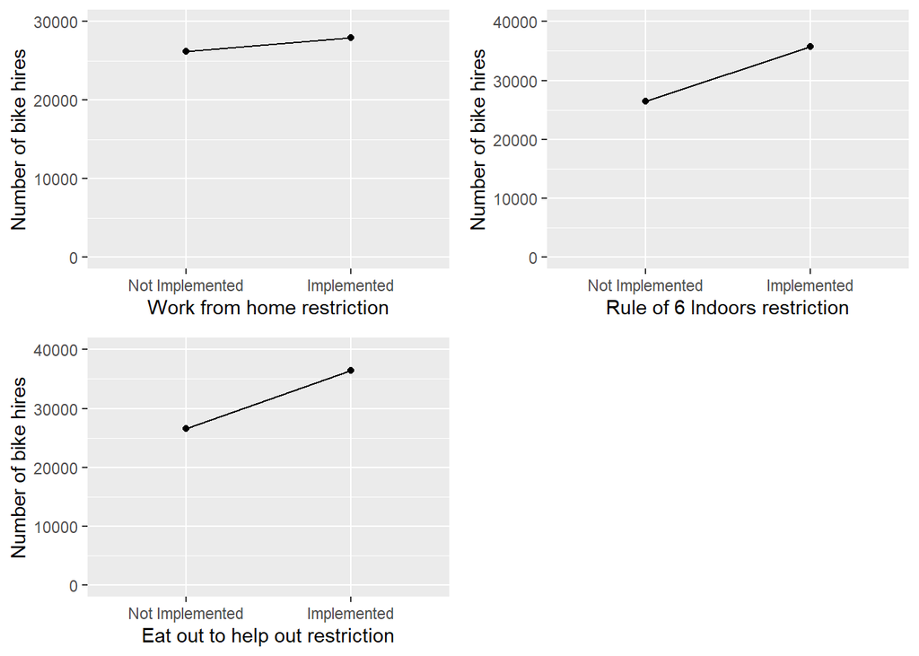

```r
#Line Chart which compares the number of bike hires when work from home restriction is implemented and when it is not implemented
m.bikes.by.wfh.emm <- emmeans(m.bikes.by.wfh, ~wfh)
summ.m.bikes.by.wfh.emm <- summary(m.bikes.by.wfh.emm)
summ.m.bikes.by.wfh.emm$wfh <- if_else(summ.m.bikes.by.wfh.emm$wfh == 0,'Not Implemented','Implemented')
summ.m.bikes.by.wfh.emm$wfh <- factor(summ.m.bikes.by.wfh.emm$wfh,c('Not Implemented','Implemented'))

ggplot1 <- ggplot(summ.m.bikes.by.wfh.emm)+ geom_line(mapping=aes(x=wfh,y=emmean),group=1)+geom_point(mapping=aes(x=wfh,y=emmean))+ylim(0,30000)+xlab('Work from home restriction') + ylab('Number of bike hires')

#Line Chart which compares the number of bike hires when rule of 6 indoors restriction is implemented and when it is not implemented
m.bikes.by.rule_of_6_indoors.emm <- emmeans(m.bikes.by.rule_of_6_indoors, ~rule_of_6_indoors)
summ.m.bikes.by.rule_of_6_indoors.emm <- summary(m.bikes.by.rule_of_6_indoors.emm)
summ.m.bikes.by.rule_of_6_indoors.emm$rule_of_6_indoors <- if_else(summ.m.bikes.by.rule_of_6_indoors.emm$rule_of_6_indoors == 0,'Not Implemented','Implemented')
summ.m.bikes.by.rule_of_6_indoors.emm$rule_of_6_indoors <- factor(summ.m.bikes.by.rule_of_6_indoors.emm$rule_of_6_indoors,c('Not Implemented','Implemented'))
ggplot2 <- ggplot(summ.m.bikes.by.rule_of_6_indoors.emm)+geom_line(mapping=aes(x=rule_of_6_indoors,y=emmean),group=1)+geom_point(mapping=aes(x=rule_of_6_indoors,y=emmean))+ylim(0,40000)+xlab('Rule of 6 Indoors restriction') + ylab('Number of bike hires')

#Line Chart which compares the number of bike hires when eat out to help out restriction is implemented and when it is not implemented

m.bikes.by.eat_out_to_help_out.emm <- emmeans(m.bikes.by.eat_out_to_help_out, ~eat_out_to_help_out)
summ.m.bikes.by.eat_out_to_help_out.emm <- summary(m.bikes.by.eat_out_to_help_out.emm)
summ.m.bikes.by.eat_out_to_help_out.emm$eat_out_to_help_out <- if_else(summ.m.bikes.by.eat_out_to_help_out.emm$eat_out_to_help_out == 0,'Not Implemented','Implemented')
summ.m.bikes.by.eat_out_to_help_out.emm$eat_out_to_help_out <- factor(summ.m.bikes.by.eat_out_to_help_out.emm$eat_out_to_help_out,c('Not Implemented','Implemented'))

ggplot3 <- ggplot(summ.m.bikes.by.eat_out_to_help_out.emm)+geom_line(mapping=aes(x=eat_out_to_help_out,y=emmean),group=1)+geom_point(mapping=aes(x=eat_out_to_help_out,y=emmean))+ylim(0,40000)+xlab('Eat out to help out restriction') + ylab('Number of bike hires')

#Arrange the line charts for each restriction
grid.arrange(ggplot1,ggplot2,ggplot3,nrow(2))
```

Figure 1: Line Chart to highlight the difference in bike hires during the implementation of Work from home, Rule of 6 Indoors, Eat out to help out restrictions.

### Multiple Regression- Model Comparison to check if there is significant improvement

```r
#Regression Model to check the effect of Work from home, Rule of 6 Indoors, Eat out to help out restrictions by adding control over each of these effects

m.bikes.by.restr <- lm(Hires~wfh+eat_out_to_help_out+rule_of_6_indoors, bikes_data)

summary(m.bikes.by.restr)
```

```
##
## Call:
## lm(formula = Hires ~ wfh + eat_out_to_help_out + rule_of_6_indoors,
##     data = bikes_data)
##
## Residuals:
##    Min     1Q Median     3Q    Max
## -27287  -6735   -227   6841  46985
##
## Coefficients:
##                      Estimate Std. Error t value Pr(>|t|)
## (Intercept)           26109.1      157.5 165.734  < 2e-16 ***
## wfh1                   1177.9      338.8   3.476 0.000513 ***
## eat_out_to_help_out1  10309.3     1815.2   5.680 1.43e-08 ***
## rule_of_6_indoors1     8542.4     1014.8   8.418  < 2e-16 ***
## ---
## Signif. codes:  0 '***' 0.001 '**' 0.01 '*' 0.05 '.' 0.1 ' ' 1
##
## Residual standard error: 9569 on 4808 degrees of freedom
## Multiple R-squared:  0.0267, Adjusted R-squared:  0.02609
## F-statistic: 43.96 on 3 and 4808 DF,  p-value: < 2.2e-16
```

```r
#Regression Model to check the effect of Work from home, Rule of 6 Indoors, Eat out to help out restrictions by adding the interaction between these effects
m.bikes.by.restr.int <- lm(Hires~wfh*eat_out_to_help_out*rule_of_6_indoors, bikes_data)

summary(m.bikes.by.restr.int)
```

```
##
## Call:
## lm(formula = Hires ~ wfh * eat_out_to_help_out * rule_of_6_indoors,
##     data = bikes_data)
##
## Residuals:
##    Min     1Q Median     3Q    Max
## -27351  -6745   -245   6849  47002
##
## Coefficients: (3 not defined because of singularities)
##                                              Estimate Std. Error t value
## (Intercept)                                   26091.8      157.6 165.548
## wfh1                                           1258.8      340.2   3.700
## eat_out_to_help_out1                          10326.6     1814.2   5.692
## rule_of_6_indoors1                            16544.7     3384.9   4.888
## wfh1:eat_out_to_help_out1                          NA         NA      NA
## wfh1:rule_of_6_indoors1                       -8791.8     3547.9  -2.478
## eat_out_to_help_out1:rule_of_6_indoors1            NA         NA      NA
## wfh1:eat_out_to_help_out1:rule_of_6_indoors1       NA         NA      NA
##                                              Pr(>|t|)
## (Intercept)                                   < 2e-16 ***
## wfh1                                         0.000218 ***
## eat_out_to_help_out1                         1.33e-08 ***
## rule_of_6_indoors1                           1.05e-06 ***
## wfh1:eat_out_to_help_out1                          NA
## wfh1:rule_of_6_indoors1                      0.013246 *
## eat_out_to_help_out1:rule_of_6_indoors1            NA
## wfh1:eat_out_to_help_out1:rule_of_6_indoors1       NA
## ---
## Signif. codes:  0 '***' 0.001 '**' 0.01 '*' 0.05 '.' 0.1 ' ' 1
##
## Residual standard error: 9564 on 4807 degrees of freedom
## Multiple R-squared:  0.02794,    Adjusted R-squared:  0.02713
## F-statistic: 34.54 on 4 and 4807 DF,  p-value: < 2.2e-16
```

This interaction term tells there is a significant difference between  
(1) the difference in bike hires during work from home implementation when Rule of 6 Indoors was not implemented ,and  
(2) the difference in bike hires during work from home implementation when Rule of 6 Indoors was implemented

```r
#Model comparison to check if adding the additional interaction term improves the model
anova(m.bikes.by.restr,m.bikes.by.restr.int)
```

```
## Analysis of Variance Table
##
## Model 1: Hires ~ wfh + eat_out_to_help_out + rule_of_6_indoors
## Model 2: Hires ~ wfh * eat_out_to_help_out * rule_of_6_indoors
##   Res.Df        RSS Df Sum of Sq      F  Pr(>F)
## 1   4808 4.4022e+11
## 2   4807 4.3966e+11  1 561618637 6.1404 0.01325 *
## ---
## Signif. codes:  0 '***' 0.001 '**' 0.01 '*' 0.05 '.' 0.1 ' ' 1
```

On addition of the interaction term, there is a significant improvement in the model when compared to the model that predicted the estimates with control over effects. With the interaction term in the model, the model comparison test shows that the overall model fit is significantly improved (F(1,4807) = 6.1404, p = 0.013)

## Regression Analysis- To check if it is appropriate to control for the effect of potential differences between different years, months, and days

### Regression Model to check for the effect of Work from Home Restriction with control of year,month and day effects.

```r
#Estimated Marginal Means of the number of bike hires during Work from home implementation
(  m.bikes.by.wfh.emm )
```

```
##  wfh emmean  SE   df lower.CL upper.CL
##  0    26205 159 4810    25894    26516
##  1    27974 292 4810    27401    28547
##
## Confidence level used: 0.95
```

```r
#Regression Model to check the for the effect of Work from Home Restriction with control of year,month and day effects

m.bikes.by.wfh.year.month.day <- lm(Hires~wfh+year+month+day, bikes_data)
(  m.bikes.by.wfh.year.month.day.emm <- emmeans(m.bikes.by.wfh.year.month.day, ~wfh)  )
```

```
##  wfh emmean  SE   df lower.CL upper.CL
##  0    27089 151 4780    26794    27384
##  1    22150 396 4780    21374    22925
##
## Results are averaged over the levels of: year, month, day
## Confidence level used: 0.95
```

```r
#Model comparison to check if having the additional control over the effect of year, month and day improves the model
anova(m.bikes.by.wfh,m.bikes.by.wfh.year.month.day)
```

```
## Analysis of Variance Table
##
## Model 1: Hires ~ wfh
## Model 2: Hires ~ wfh + year + month + day
##   Res.Df        RSS Df  Sum of Sq      F    Pr(>F)
## 1   4810 4.4965e+11
## 2   4780 1.9324e+11 30 2.5641e+11 211.41 < 2.2e-16 ***
## ---
## Signif. codes:  0 '***' 0.001 '**' 0.01 '*' 0.05 '.' 0.1 ' ' 1
```

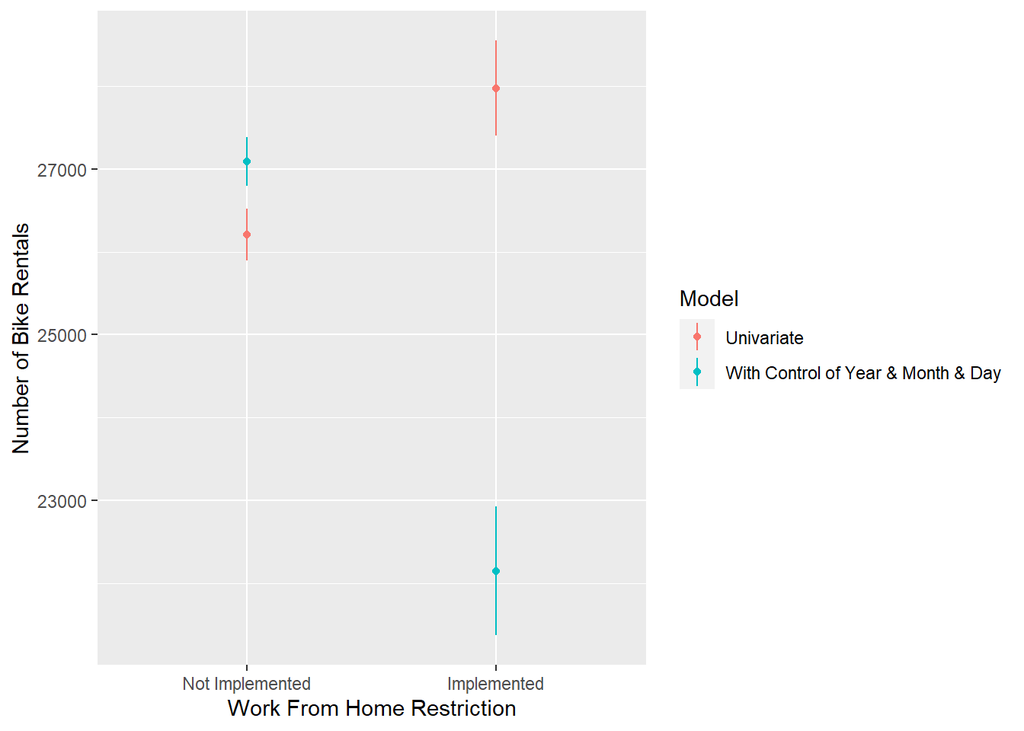

```r
#Data Frame to summarize the results of the simple regression model and multiple regression model which controls for the effect of year,month and day

m.bikes.by.wfh.emm.summary <- summary(m.bikes.by.wfh.emm)
m.bikes.by.wfh.emm.summary$model <- "Univariate"
m.bikes.by.wfh.year.month.day.emm.summary <- summary(m.bikes.by.wfh.year.month.day.emm)
m.bikes.by.wfh.year.month.day.emm.summary$model <- "With Control of Year & Month & Day"
m.gain.two.models.emm.summary <- rbind(m.bikes.by.wfh.emm.summary, m.bikes.by.wfh.year.month.day.emm.summary)
m.gain.two.models.emm.summary$wfh <- if_else(m.gain.two.models.emm.summary$wfh == 0,'Not Implemented','Implemented')
m.gain.two.models.emm.summary$wfh <- factor(m.gain.two.models.emm.summary$wfh,c('Not Implemented','Implemented'))

#Line Range plot to highlight the difference in the bike hires when controlling for the effect of year,day and month
ggplot(m.gain.two.models.emm.summary, aes(x=wfh, y=emmean, ymin=lower.CL, ymax=upper.CL, col=model)) + geom_point() + geom_linerange() + labs(x="Work From Home Restriction", y="Number of Bike Rentals", col="Model")
```

Line Range analysis illustrates that there is an increase in bike hires in the Univariate Model which does not include the control effect of year,month and day. However, there is decrease in bike hires observed for the model which includes the control effect of year,month and day.

### Regression Model to check for the effect of Rule of Six Indoors Restriction with control for the effect of year,day and month

```r
## Controlling for the effect of year, month and day

#Estimated Marginal Means of the number of bike hires during Rule of 6 Indoors implementation
(m.bikes.by.rule_of_6_indoors.emm)
```

```
##  rule_of_6_indoors emmean  SE   df lower.CL upper.CL
##  0                  26422 140 4810    26147    26696
##  1                  35731 981 4810    33809    37654
##
## Confidence level used: 0.95
```

```r
#Regression Model to check the for the effect of Rule of 6 Indoors Restriction with control of year,month and day effects

m.bikes.by.rule_of_6_indoors.year.month.day <- lm(Hires~rule_of_6_indoors+year+month+day, bikes_data)
(  m.bikes.by.rule_of_6_indoors.year.month.day.emm <- emmeans(m.bikes.by.rule_of_6_indoors.year.month.day,~rule_of_6_indoors)  )
```

```
##  rule_of_6_indoors emmean    SE   df lower.CL upper.CL
##  0                  25914  96.3 4780    25726    26103
##  1                  26886 714.9 4780    25485    28288
##
## Results are averaged over the levels of: year, month, day
## Confidence level used: 0.95
```

```r
#Model comparison to check if having the additional control over the effect of year, month and day improves the model
anova(m.bikes.by.rule_of_6_indoors,m.bikes.by.rule_of_6_indoors.year.month.day)
```

```
## Analysis of Variance Table
##
## Model 1: Hires ~ rule_of_6_indoors
## Model 2: Hires ~ rule_of_6_indoors + year + month + day
##   Res.Df        RSS Df  Sum of Sq      F    Pr(>F)
## 1   4810 4.4414e+11
## 2   4780 1.9709e+11 30 2.4705e+11 199.73 < 2.2e-16 ***
## ---
## Signif. codes:  0 '***' 0.001 '**' 0.01 '*' 0.05 '.' 0.1 ' ' 1
```

Without control when bike hires are directly compared when rule of 6 indoors scheme was implemented, differences in bike hires is much larger. With control for year, month and day, a model comparison test shows that the overall model fit is significantly improved (F(30,4780) = 199.73, p < 0.05)

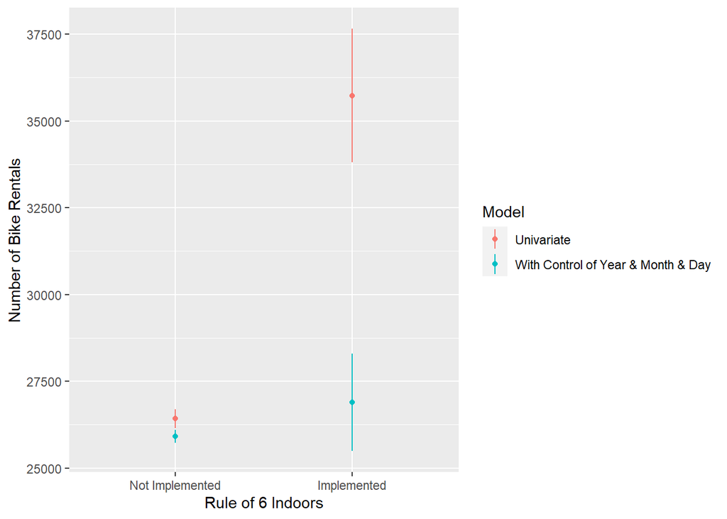

```r
#Data Frame to summarize the results of the simple regression model and multiple regression model which controls for the effect of year,month and day

m.bikes.by.rule_of_6_indoors.emm.summary <- summary(m.bikes.by.rule_of_6_indoors.emm)
m.bikes.by.rule_of_6_indoors.emm.summary$model <- "Univariate"
m.bikes.by.rule_of_6_indoors.year.month.day.emm.summary <- summary(m.bikes.by.rule_of_6_indoors.year.month.day.emm)
m.bikes.by.rule_of_6_indoors.year.month.day.emm.summary$model <- "With Control of Year & Month & Day"
m.gain.two.models.1.emm.summary <- rbind(m.bikes.by.rule_of_6_indoors.emm.summary, m.bikes.by.rule_of_6_indoors.year.month.day.emm.summary)
m.gain.two.models.1.emm.summary$rule_of_6_indoors <- if_else(m.gain.two.models.1.emm.summary$rule_of_6_indoors == 0,'Not Implemented','Implemented')
m.gain.two.models.1.emm.summary$rule_of_6_indoors <- factor(m.gain.two.models.1.emm.summary$rule_of_6_indoors,c('Not Implemented','Implemented'))

#Line Range plot to highlight the difference in the bike hires when controlling for the effect of year,day and month

ggplot(m.gain.two.models.1.emm.summary, aes(x=rule_of_6_indoors, y=emmean, ymin=lower.CL, ymax=upper.CL, col=model)) + geom_point() + geom_linerange() + labs(x="Rule of 6 Indoors", y="Number of Bike Rentals", col="Model")
```

Line Range analysis illustrates that there is an increase in bike hires in the Univariate Model which does not include the control effect of year,month and day. There is also an increase in bike hires observed for the model which includes the control effect of year,month and day.

### Regression Model to check for the effect of Eat Out to Help Out with control for the effect of year, day and month

```r
## Controlling for the effect of year, month and day

#Estimated Marginal Means of the number of bike hires during Eat out to Help out implementation
(m.bikes.by.eat_out_to_help_out.emm)
```

```
##  eat_out_to_help_out emmean   SE   df lower.CL upper.CL
##  0                    26550  140 4810    26276    26824
##  1                    36418 1827 4810    32837    40000
##
## Confidence level used: 0.95
```

```r
#Regression Model to check the for the effect of Eat out to Help out Restriction with control of year,month and day effects
m.bikes.by.eat_out_to_help_out.year.month.day <- lm(Hires~eat_out_to_help_out+year+month+day, bikes_data)
(  m.bikes.by.eat_out_to_help_out.year.month.day.emm <- emmeans(m.bikes.by.eat_out_to_help_out.year.month.day,~eat_out_to_help_out)  )
```

```
##  eat_out_to_help_out emmean     SE   df lower.CL upper.CL
##  0                    25920   95.5 4780    25733    26107
##  1                    28562 1302.8 4780    26008    31116
##
## Results are averaged over the levels of: year, month, day
## Confidence level used: 0.95
```

```r
#Model comparison to check if having the additional control over the effect of year, month and day improves the model
anova(m.bikes.by.rule_of_6_indoors,m.bikes.by.eat_out_to_help_out.year.month.day)
```

```
## Analysis of Variance Table
##
## Model 1: Hires ~ rule_of_6_indoors
## Model 2: Hires ~ eat_out_to_help_out + year + month + day
##   Res.Df        RSS Df  Sum of Sq     F    Pr(>F)
## 1   4810 4.4414e+11
## 2   4780 1.9699e+11 30 2.4715e+11 199.9 < 2.2e-16 ***
## ---
## Signif. codes:  0 '***' 0.001 '**' 0.01 '*' 0.05 '.' 0.1 ' ' 1
```

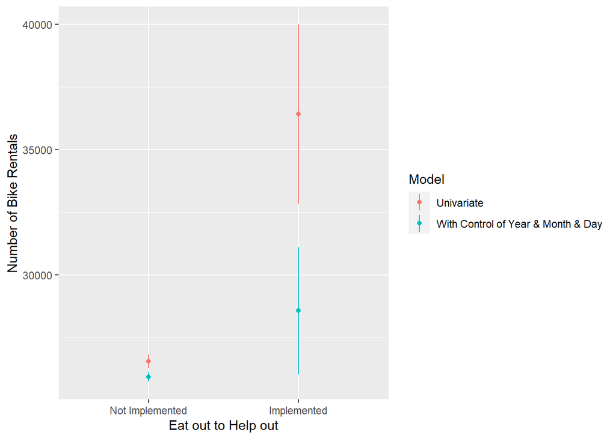

```r
#Data Frame to summarize the results of the simple regression model and multiple regression model which controls for the effect of year,month and day

m.bikes.by.eat_out_to_help_out.emm.summary <- summary(m.bikes.by.eat_out_to_help_out.emm)
m.bikes.by.eat_out_to_help_out.emm.summary$model <- "Univariate"
m.bikes.by.eat_out_to_help_out.year.month.day.emm.summary <- summary(m.bikes.by.eat_out_to_help_out.year.month.day.emm)
m.bikes.by.eat_out_to_help_out.year.month.day.emm.summary$model <- "With Control of Year & Month & Day"
m.gain.two.models.2.emm.summary <- rbind(m.bikes.by.eat_out_to_help_out.emm.summary, m.bikes.by.eat_out_to_help_out.year.month.day.emm.summary)
m.gain.two.models.2.emm.summary$eat_out_to_help_out <- if_else(m.gain.two.models.2.emm.summary$eat_out_to_help_out == 0,'Not Implemented','Implemented')
m.gain.two.models.2.emm.summary$eat_out_to_help_out <- factor(m.gain.two.models.2.emm.summary$eat_out_to_help_out,c('Not Implemented','Implemented'))

#Line Range plot to highlight the difference in the bike hires when controlling for the effect of year,day and month

ggplot(m.gain.two.models.2.emm.summary, aes(x=eat_out_to_help_out, y=emmean, ymin=lower.CL, ymax=upper.CL, col=model)) + geom_point() + geom_linerange() + labs(x="Eat out to Help out", y="Number of Bike Rentals", col="Model")
```

Line Range analysis illustrates that there is an increase in bike hires in the Uni variate Model which does not include the control effect of year,month and day. There is also an increase in bike hires observed for the model which includes the control effect of year,month and day.